# Respuestas a los ejercicios de ggplot2 Elegant Graphics for Data Analysis

Daniel Salgado

17/1/2017

Este documento fue escrito para guardar las respuestas a los ejercicios (no todos) del libro “ggplot2 Elegant Graphics for Data Analysis de Hadley Wickham”. La idea de este documento es aprovechar las ventajas de R Marckdown, incluyendo en la medida de lo posible gráficas interactivas con la ayuda de *Shiny*

## Chapter 2

Los primeros ejercicios utilizan los datos de *mpg*, cargemos los datos.

```r
library(ggplot2)
mpg
```

```
## # A tibble: 234 × 11
##    manufacturer      model displ  year   cyl      trans   drv   cty   hwy
##           <chr>      <chr> <dbl> <int> <int>      <chr> <chr> <int> <int>
## 1          audi         a4   1.8  1999     4   auto(l5)     f    18    29
## 2          audi         a4   1.8  1999     4 manual(m5)     f    21    29
## 3          audi         a4   2.0  2008     4 manual(m6)     f    20    31
## 4          audi         a4   2.0  2008     4   auto(av)     f    21    30
## 5          audi         a4   2.8  1999     6   auto(l5)     f    16    26
## 6          audi         a4   2.8  1999     6 manual(m5)     f    18    26
## 7          audi         a4   3.1  2008     6   auto(av)     f    18    27
## 8          audi a4 quattro   1.8  1999     4 manual(m5)     4    18    26
## 9          audi a4 quattro   1.8  1999     4   auto(l5)     4    16    25
## 10         audi a4 quattro   2.0  2008     4 manual(m6)     4    20    28
## # ... with 224 more rows, and 2 more variables: fl <chr>, class <chr>
```

Ya con los datos cargados podemos reproducir la primer gráfica del libro.

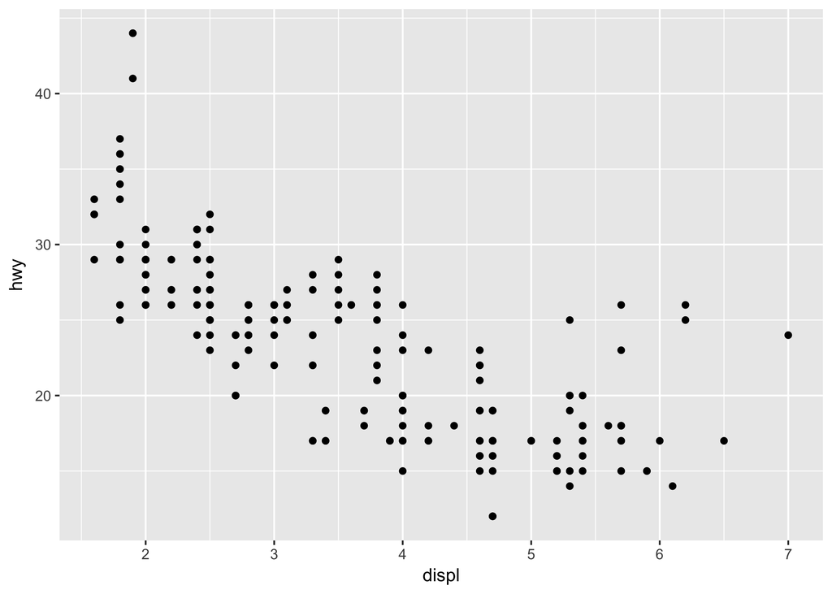

```r
ggplot(mpg, aes(displ, hwy)) +
  geom_point()
```

Esta gráfica muestra en el eje vertical las millas por galon en carretera (variable *hwy*) de los modelos registrados en el dataset, en el eje horizontal tenemos la variable *displ* que representa el desplazamiento del motor.

### 2.3.1 Answers

#### 1

La relaciòn entre *cty* (las millas por galon en ciudad) y *hwy* se puede observar claramente en la siguiente gráfica.

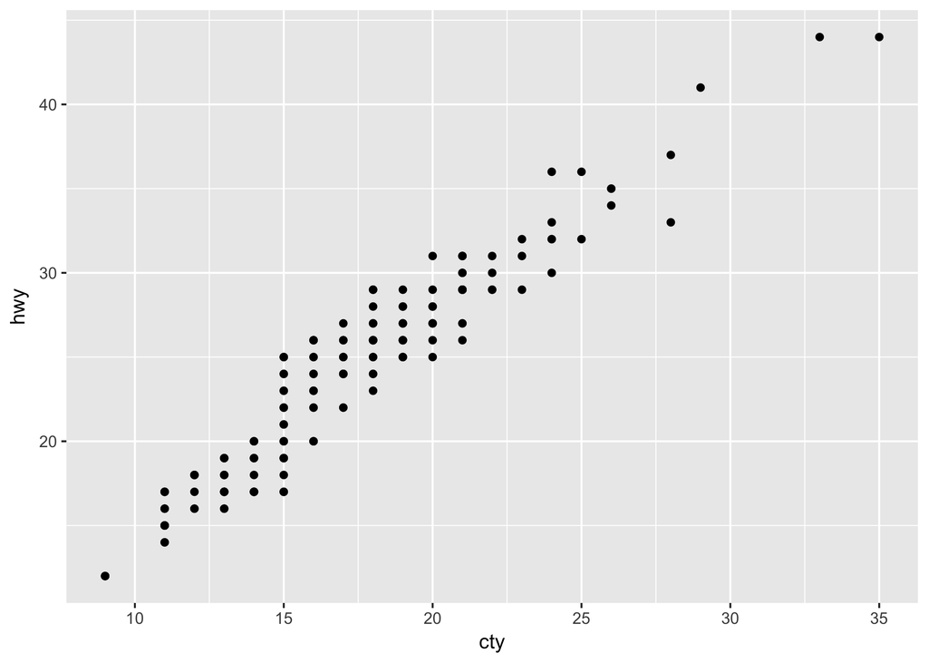

```r
ggplot(mpg, aes(cty, hwy)) +
  geom_point()
```

#### 2

Al gráficar

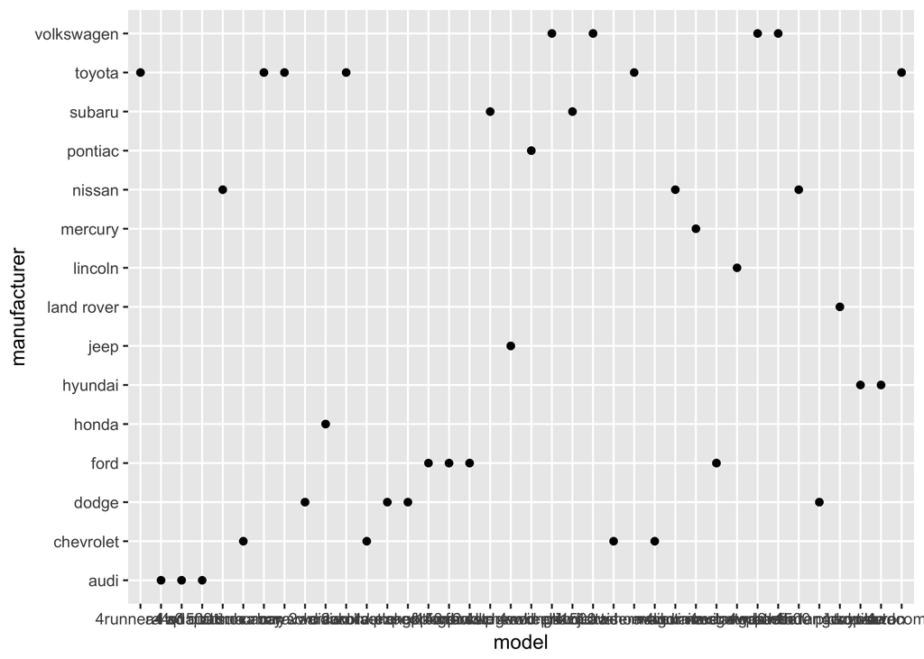

```r
ggplot(mpg, aes(model, manufacturer)) +
  geom_point()
```

Se crea una gráfica en de disperción de dos variables categoricas, en el eje x tenemos el modelo de todas nuestras observaciones y en el vertical las marcas de autos.

#### 3

##### a)

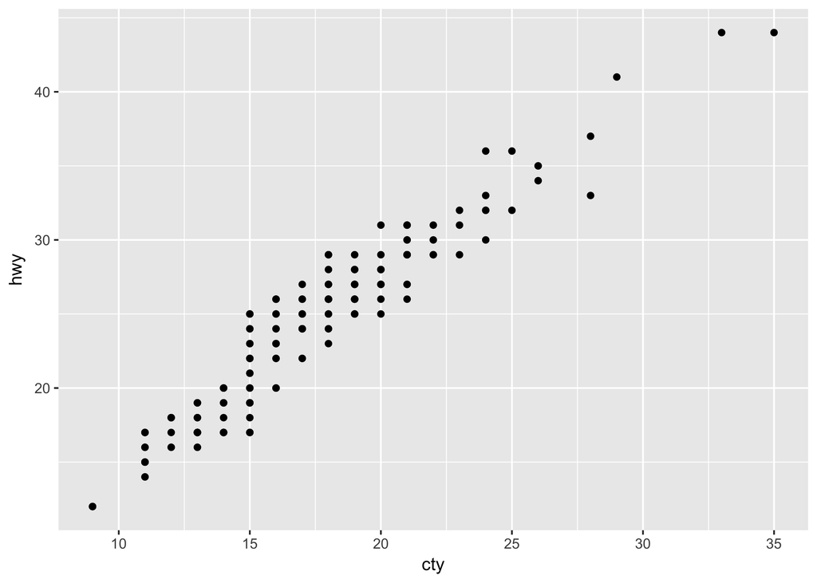

```r
ggplot(mpg, aes(cty, hwy)) + geom_point()
```

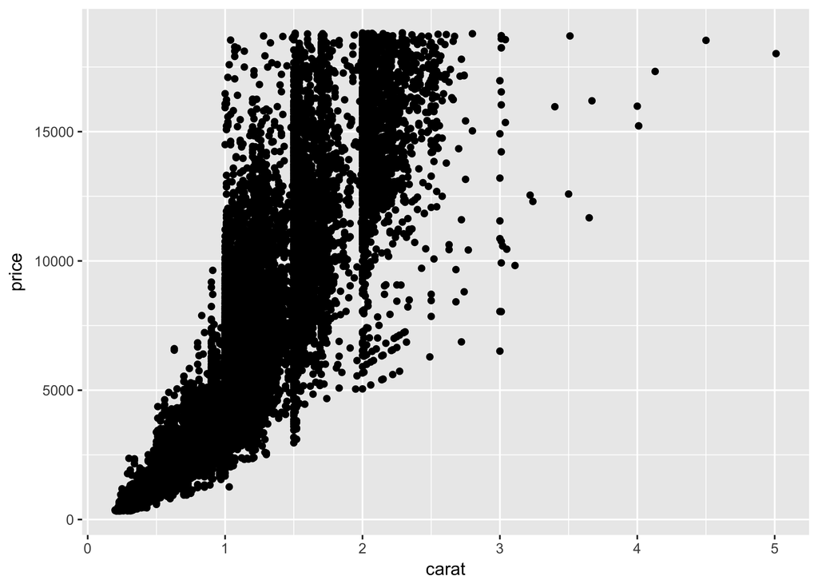

```r
ggplot(diamonds, aes(carat, price)) + geom_point()
```

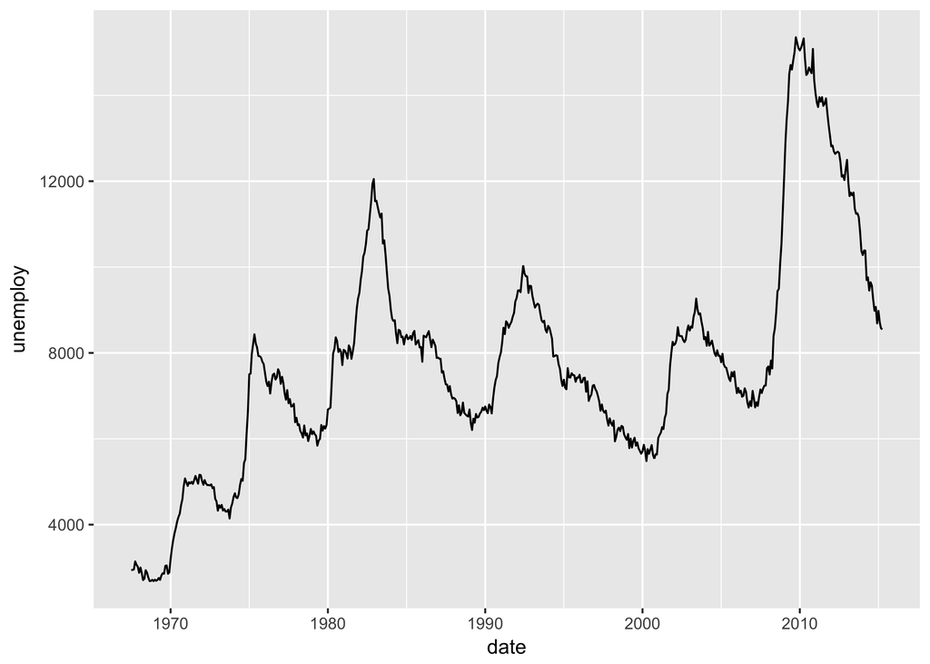

```r
ggplot(economics, aes(date, unemploy)) + geom_line()
```

data: economics aesthetics: x -> date; y -> unemploy layers: gráfica de lineas

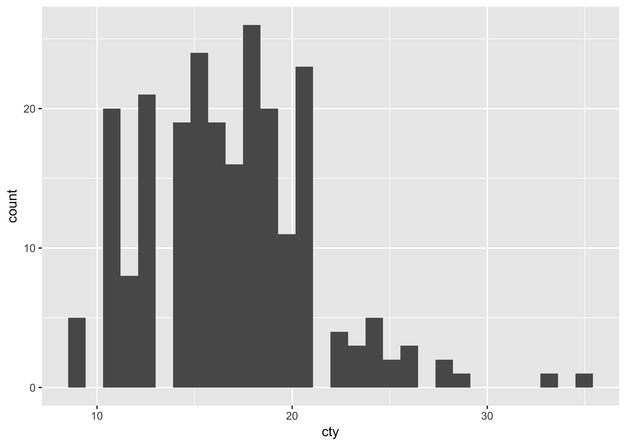

```r
ggplot(mpg, aes(cty)) + geom_histogram()
```

data: mpg aesthetics: x -> cty layers: histográma de cty